# Plot types

Generally speaking, `ggplot2` geoms specify **plot types**.  
Each **geom** produces a plot **layer** and multiple layers can be combined.  
Here we demonstrate several frequently used geoms.  
Try to regenerate the plots in your R Markdown document.

➡️Go to [RStudio Cheatsheets/Data Visualization Cheatsheet/Panel Scales](https://rstudio.com/resources/cheatsheets/) to see numerous geoms provided by the library.

➡️Go to [The R Graph Gallery](https://www.r-graph-gallery.com/) to see how R (often with ggplot2 library) can be used for data visualisation.

## Histograms

Let’s start with the histogram of the `pulse2` variable from the `pulse` data:

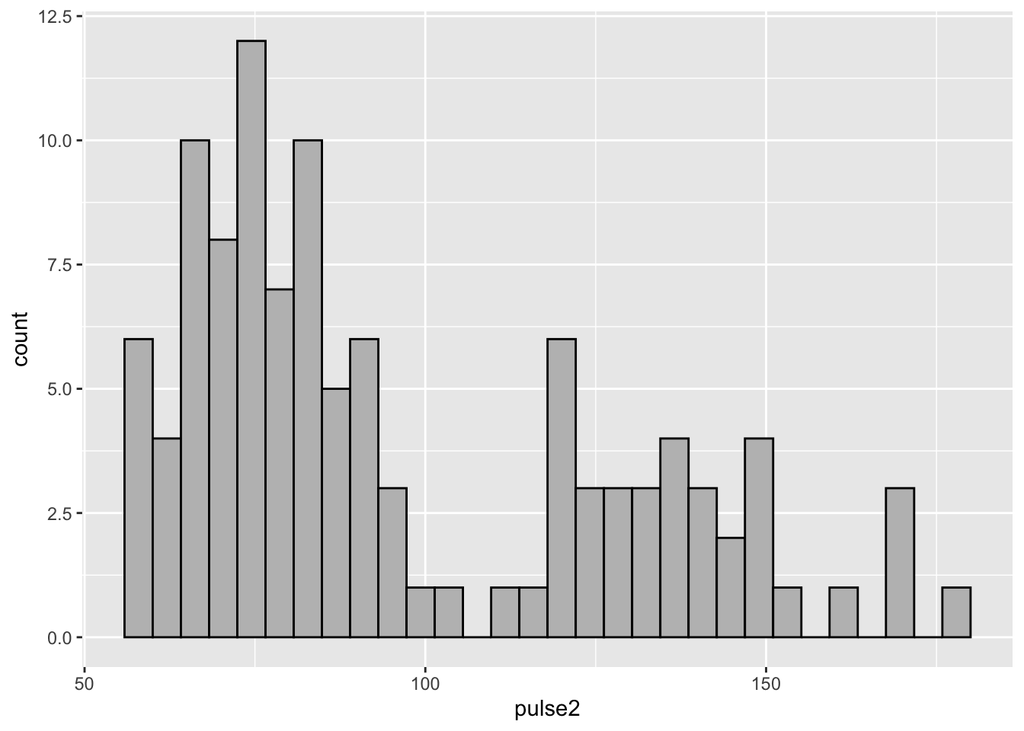

```r
ggplot( pulse ) +
  aes( x = pulse2 ) +
  geom_histogram( color = "black", fill = "gray" )
```

Note, that there were two groups of subjects: one did `run`, the other did not.  
Try to add color to split histogram bars to make groups visible:

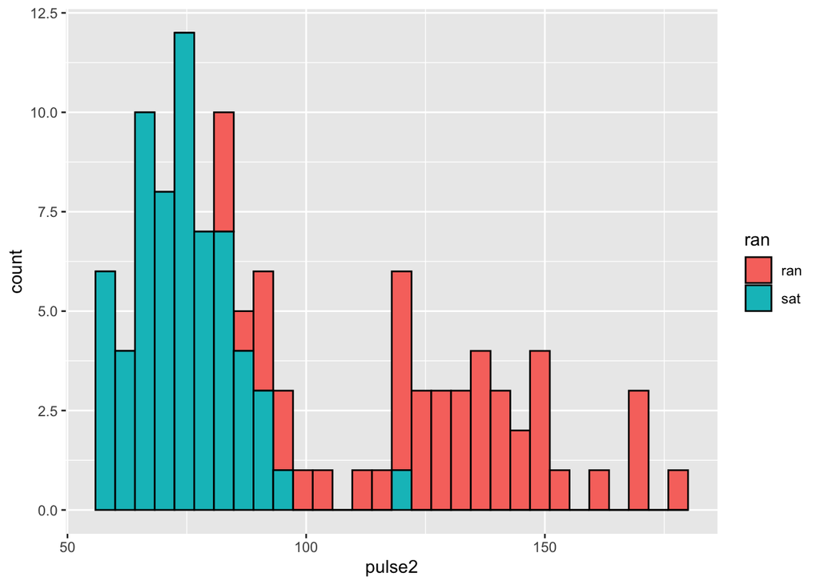

```r
ggplot( pulse ) +
  aes( x = pulse2, fill = ran ) +
  geom_histogram( color = "black" )
```

The above histogram has the **groups stacked**.  
To visualize each group separately, try to add `position` argument as below (remember to add `alpha`; otherwise some bars might get hidden):

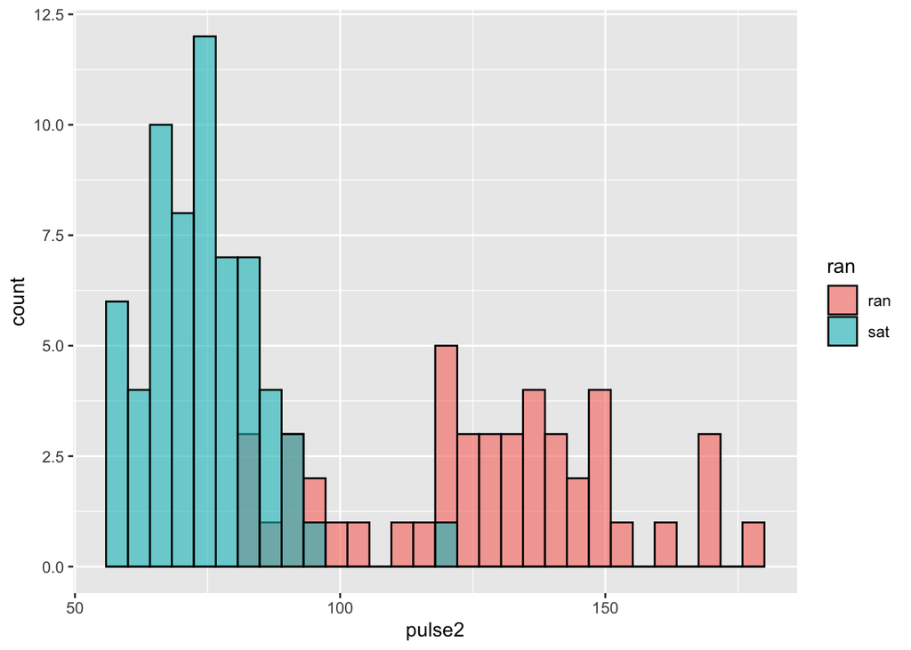

```r
ggplot( pulse ) +
  aes( x = pulse2, fill = ran ) +
  geom_histogram( color = "black", position = "identity", alpha = 0.6 )
```

An another possible value of the `position` argument:

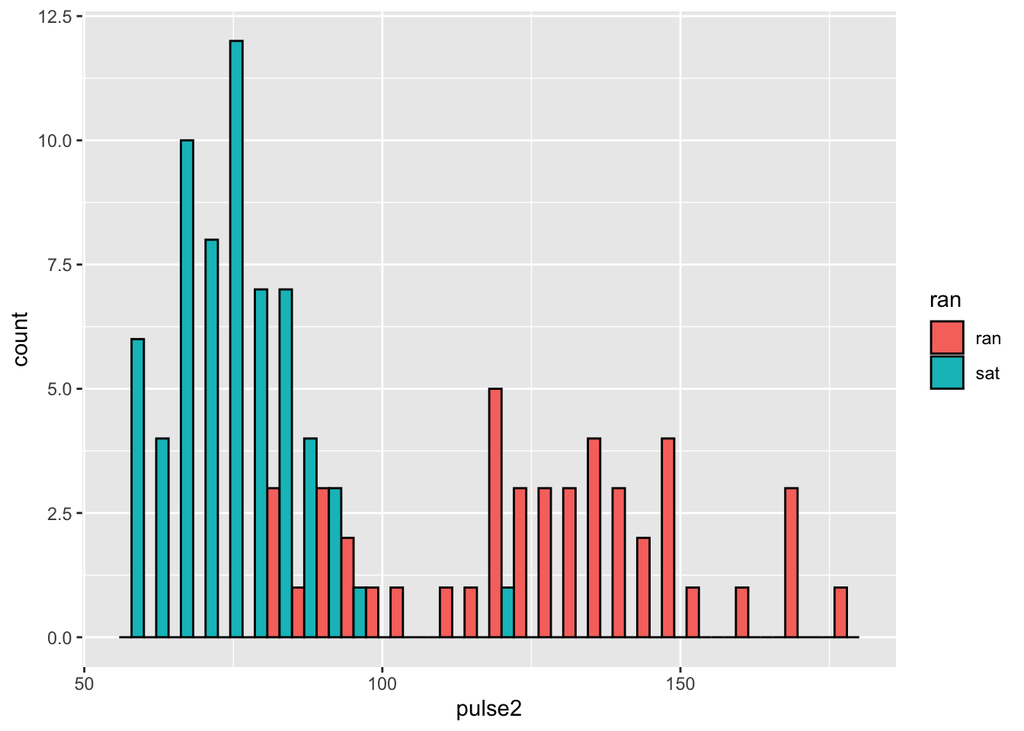

```r
ggplot( pulse ) +
  aes( x = pulse2, fill = ran ) +
  geom_histogram( color = "black", position = "dodge" )
```

## Boxplots

A **boxplot** might also be used to show the separation of the groups. Try:

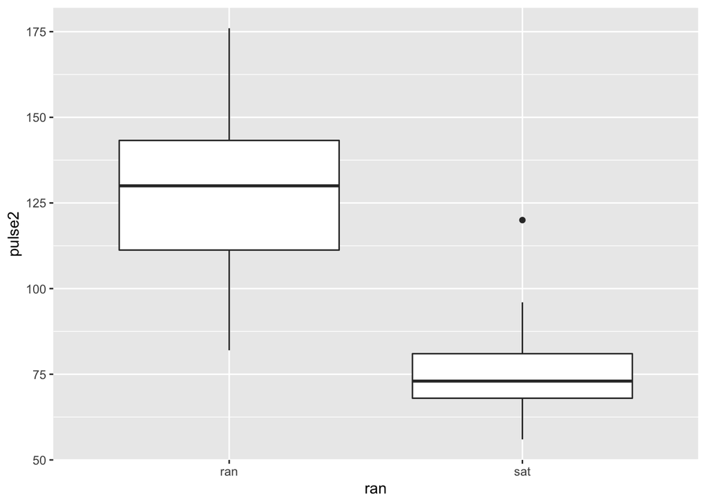

```r
ggplot( pulse ) +
  aes( x = ran, y = pulse2 ) +
  geom_boxplot()
```

The values used to calculate the boxplot can be put as an extra **layer** of points on the top of the boxes.  
This can be done with `geom_point` (note, that here the `x` axis refers to categorical data).  
To avoid double plotting of **outliers**, we disable them in `geom_boxplot` by setting their `outlier.color` to `NA`.  
Try the following:

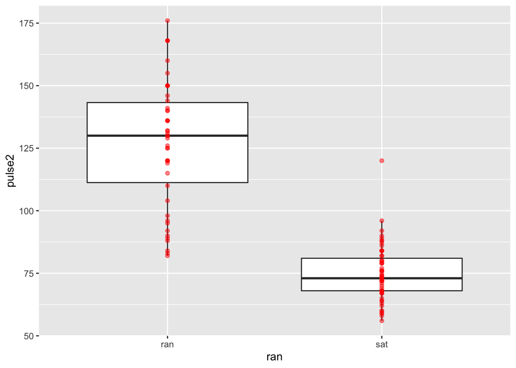

```r
ggplot( pulse ) +
  aes( x = ran, y = pulse2 ) +
  geom_boxplot( outlier.color = NA ) +
  geom_point( color = "red", alpha = 0.5 )
```

The above plot suffers from **overlap of the points**.  
`geom_jitter` (used instead of `geom_point`) allows to add noise to point locations.  
The arguments `width` and `height` specify the range of noise combined with `x` and `y` directions.  
Try:

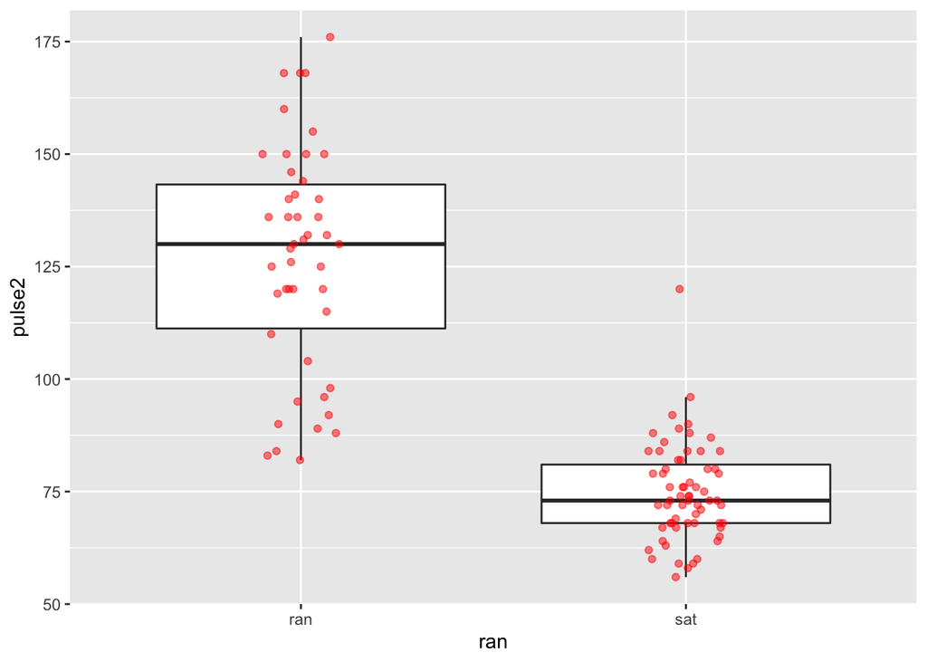

```r
ggplot( pulse ) +
  aes( x = ran, y = pulse2 ) +
  geom_boxplot( outlier.color = NA ) +
  geom_jitter( color = "red", height = 0, width = 0.1, alpha = 0.5 )
```

In some contexts **violin plots** may be more useful than the boxplots.  
Replace `geom_boxplot` with `geom_violin`:

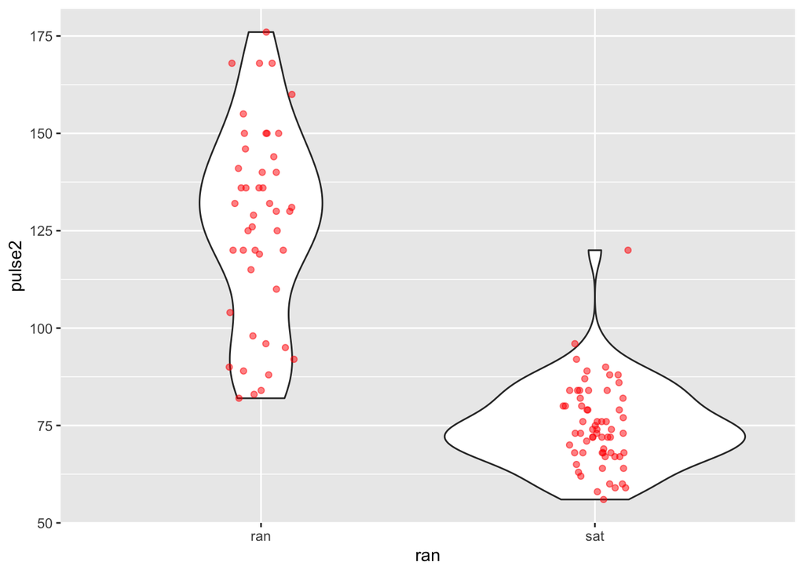

```r
ggplot( pulse ) +
  aes( x = ran, y = pulse2 ) +
  geom_violin() +
  geom_jitter( color = "red", height = 0, width = 0.1, alpha = 0.5 )
```

This can be the final combination of a boxplot, violin plot, and points plot with extra horizontal noise:

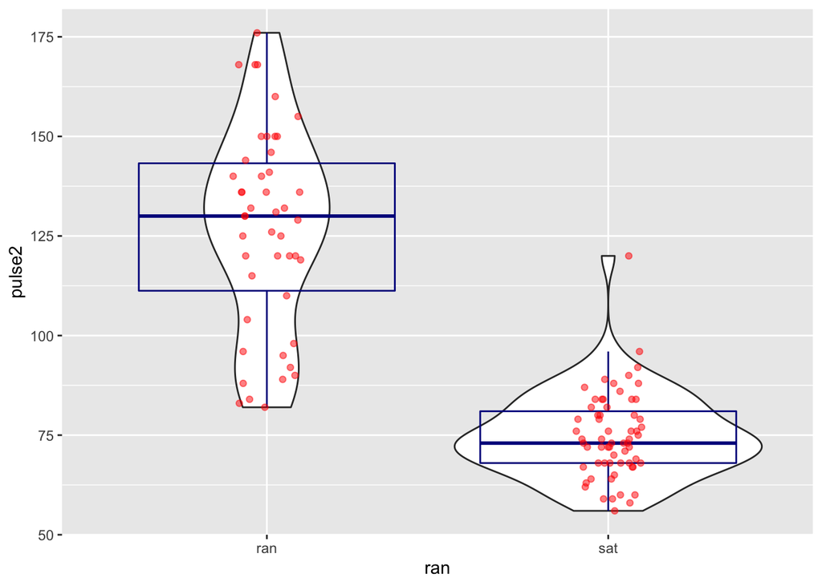

```r
ggplot( pulse ) +
  aes( x = ran, y = pulse2 ) +
  geom_violin() +
  geom_boxplot( outlier.color = NA, fill = NA, color = "darkblue" ) +
  geom_jitter( color = "red", height = 0, width = 0.1, alpha = 0.5 )
```

## A plot of texts

In some contexts it might be important to visualise words in a plot.  
Try `geom_text` as follows:

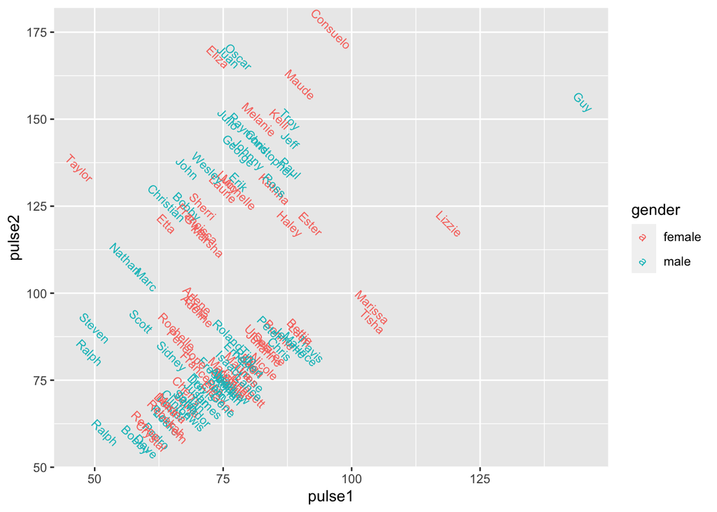

```r
ggplot( pulse ) +
  aes( x = pulse1, y = pulse2, label = name, color = gender ) +
  geom_text( angle = -45, size = 3 )
```